# RI Wood Turtle Data

# Introduction

The goal of this project is to analyze telemetry data collected over to 2022 field season on six wood turtles (3 males and 3 females), to look for patterns and differences between their homeranges and how far away the areas they are occupying are from the stream.

## Getting started

Activate necessary packages and clear R’s brain

```r
rm(list = ls())
library(dplyr)
library(ggplot2)
library(here)
library(ggfortify)
library(adehabitatHR)
library(sp)
```

## Pulling in the data

The telemetry data is the first dataset that needs to be pulled in and checked for errors

```r
turtles <- read.csv(here("Data", "RI_turtle_data.csv"), stringsAsFactors = TRUE)
```

## Check out the data

```r
str(turtles) #shows the data frame
```

[output not shown]

Check the levels for the columns Turtle_ID and Turtle_sex. There should be six and two levels respectively.

```r
levels(turtles$Turtle_ID)
levels(turtles$Turtle_sex)
```

[output not shown]

The Latitudes and Longitudes can be checked for errors by using histograms

First, the latitudes

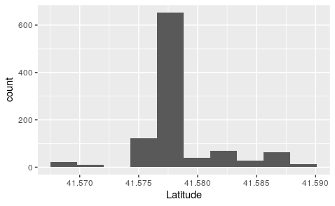

```r
ggplot(turtles, aes(x = Latitude)) +
  geom_histogram(bins = 10)
```

Looks good! Slight variation is expected and the large number of counts in the center is great as well because these turtles all live along the same river.

Now, the longitudes

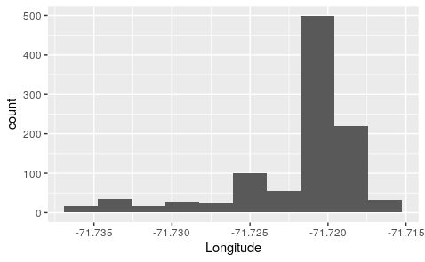

```r
ggplot(turtles, aes(x = Longitude)) +
  geom_histogram(bins = 10)
```

Looks great!

Before we can calculate the home ranges for each turtle, we need to generate subsets that sort the data by each individual.

```r
L1R2_male <- filter(turtles, Turtle_ID == "L1R2")
L3R1_male <- filter(turtles, Turtle_ID == "L3R1")
L9R0_male <- filter(turtles, Turtle_ID == "L9R0")
L1R4_female <- filter(turtles, Turtle_ID == "L1R4")
L3R3_female <- filter(turtles, Turtle_ID == "L3R3")
L3R9_female <- filter(turtles, Turtle_ID == "L3R9")
```